# An Introduction to Statistical Learning (2013)

Solutions to Applied Exercises

by Brian Hassett

# Chapter 4 Classification

This notebook is a rough outline of solutions to the applied exercises in Chapter 4 of **An Introduction to Statistical Learning** (James et al. (2013)[^1]).

## Setup

```r
library(ISLR)
library(tidyverse)
library(MASS)
library(patchwork)
library(GGally)
theme_set(theme_bw())

# Given a filename, return the filepath. Default folder is the `data` folder in the current working directory.
get_path <- function(filename) {
  str_c(getwd(), "data", filename, sep = "/")
}

# Colors:
ISLR_blue <- "#176FC0"
ISLR_brown <- "#94340E"

# Return vector of the names of numeric columns in a data frame:
numeric_cols <- function(df) {
  is_numeric_cols <- map_lgl(df, is.numeric)
  return(names(df)[is_numeric_cols])
}

# Print accuracy, test rate and table of predicted labels and true labels:
test_rates <- function(predicted_label, test_label) {
  print(table(predicted_label, test_label))
  test_accuracy <- mean(predicted_label == test_label)*100
  test_error <- mean(predicted_label != test_label)*100
  print(str_interp("Test accuracy: ${round(test_accuracy, 2)}"))
  print(str_interp("Test error rate: ${round(test_error, 2)}"))
}

# Load my functions:
source("/home/brian/R/dir/Util/bh_functions.R")
```

## Exercise 10

### (a)

View data:

```r
Weekly
```

|  | Year | Lag1 | Lag2 | Lag3 | Lag4 | Lag5 | Volume | Today | Direction |
| --- | --- | --- | --- | --- | --- | --- | --- | --- | --- |
| 1 | 1990 | 0.816 | 1.572 | -3.936 | -0.229 | -3.484 | 0.1549760 | -0.270 | Down |
| 2 | 1990 | -0.270 | 0.816 | 1.572 | -3.936 | -0.229 | 0.1485740 | -2.576 | Down |
| 3 | 1990 | -2.576 | -0.270 | 0.816 | 1.572 | -3.936 | 0.1598375 | 3.514 | Up |
| 4 | 1990 | 3.514 | -2.576 | -0.270 | 0.816 | 1.572 | 0.1616300 | 0.712 | Up |
| 5 | 1990 | 0.712 | 3.514 | -2.576 | -0.270 | 0.816 | 0.1537280 | 1.178 | Up |
| 6 | 1990 | 1.178 | 0.712 | 3.514 | -2.576 | -0.270 | 0.1544440 | -1.372 | Down |
| 7 | 1990 | -1.372 | 1.178 | 0.712 | 3.514 | -2.576 | 0.1517220 | 0.807 | Up |
| 8 | 1990 | 0.807 | -1.372 | 1.178 | 0.712 | 3.514 | 0.1323100 | 0.041 | Up |
| 9 | 1990 | 0.041 | 0.807 | -1.372 | 1.178 | 0.712 | 0.1439720 | 1.253 | Up |
| 10 | 1990 | 1.253 | 0.041 | 0.807 | -1.372 | 1.178 | 0.1336350 | -2.678 | Down |

[output cut: 990 more lines]

Summary:

```r
bh_print_data_summary(Weekly)
```

```
                      [,1]
num_rows              " 1,089"
num_cols              "     9"
num_categorical_cols  "     1"
num_numeric_cols      "     8"
all_missing_cols      "     0"
complete_cols         "     9"
total_missing         "     0"
total_percent_missing "     0"
total_data_points     " 9,801"
size_bytes            "76,376"
```

```r
summary(Weekly)
```

```
      Year           Lag1               Lag2               Lag3               Lag4               Lag5              Volume            Today
 Min.   :1990   Min.   :-18.1950   Min.   :-18.1950   Min.   :-18.1950   Min.   :-18.1950   Min.   :-18.1950   Min.   :0.08747   Min.   :-18.1950
 1st Qu.:1995   1st Qu.: -1.1540   1st Qu.: -1.1540   1st Qu.: -1.1580   1st Qu.: -1.1580   1st Qu.: -1.1660   1st Qu.:0.33202   1st Qu.: -1.1540
 Median :2000   Median :  0.2410   Median :  0.2410   Median :  0.2410   Median :  0.2380   Median :  0.2340   Median :1.00268   Median :  0.2410
 Mean   :2000   Mean   :  0.1506   Mean   :  0.1511   Mean   :  0.1472   Mean   :  0.1458   Mean   :  0.1399   Mean   :1.57462   Mean   :  0.1499
 3rd Qu.:2005   3rd Qu.:  1.4050   3rd Qu.:  1.4090   3rd Qu.:  1.4090   3rd Qu.:  1.4090   3rd Qu.:  1.4050   3rd Qu.:2.05373   3rd Qu.:  1.4050
 Max.   :2010   Max.   : 12.0260   Max.   : 12.0260   Max.   : 12.0260   Max.   : 12.0260   Max.   : 12.0260   Max.   :9.32821   Max.   : 12.0260
 Direction
 Down:484
 Up  :605
```

Breakdown of response class, `Direction`:

```r
Weekly %>%
  count(Direction) %>%
  mutate(prop = n/sum(n))
```

|  | Direction | n | prop |
| --- | --- | --- | --- |
| 1 | Down | 484 | 0.4444444 |
| 2 | Up | 605 | 0.5555556 |

Correlations:

```r
is_numeric_cols <- map_lgl(Weekly, is.numeric)
cor(Weekly[ , is_numeric_cols])
```

```
              Year         Lag1        Lag2        Lag3         Lag4         Lag5      Volume        Today
Year    1.00000000 -0.032289274 -0.03339001 -0.03000649 -0.031127923 -0.030519101  0.84194162 -0.032459894
Lag1   -0.03228927  1.000000000 -0.07485305  0.05863568 -0.071273876 -0.008183096 -0.06495131 -0.075031842
Lag2   -0.03339001 -0.074853051  1.00000000 -0.07572091  0.058381535 -0.072499482 -0.08551314  0.059166717
Lag3   -0.03000649  0.058635682 -0.07572091  1.00000000 -0.075395865  0.060657175 -0.06928771 -0.071243639
Lag4   -0.03112792 -0.071273876  0.05838153 -0.07539587  1.000000000 -0.075675027 -0.06107462 -0.007825873
Lag5   -0.03051910 -0.008183096 -0.07249948  0.06065717 -0.075675027  1.000000000 -0.05851741  0.011012698
Volume  0.84194162 -0.064951313 -0.08551314 -0.06928771 -0.061074617 -0.058517414  1.00000000 -0.033077783
Today  -0.03245989 -0.075031842  0.05916672 -0.07124364 -0.007825873  0.011012698 -0.03307778  1.000000000
```

`Volume` over time:

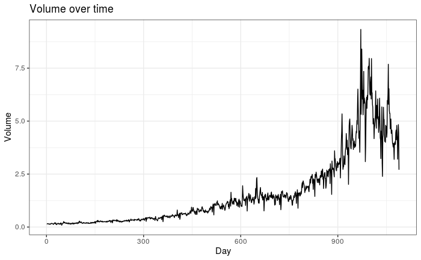

```r
ggplot(Weekly) +
  geom_line(aes(1:nrow(Weekly), Volume)) +
  labs(x = "Day", title = "Volume over time")
```

`Today` vs `Lag1`:

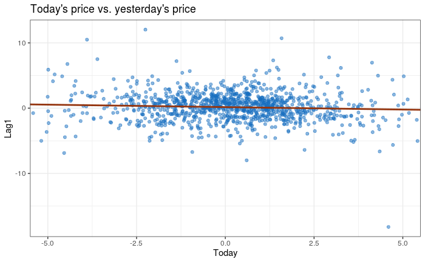

```r
ggplot(Weekly, aes(Today, Lag1)) +
  geom_point(color = ISLR_blue, alpha = 0.5) +
  geom_smooth(method = "lm", se = FALSE,
              color = ISLR_brown) +
  ggtitle("Today's price vs. yesterday's price") +
  coord_cartesian(xlim = c(-5, 5)) # zoom in
```

Histograms for all numeric variables:

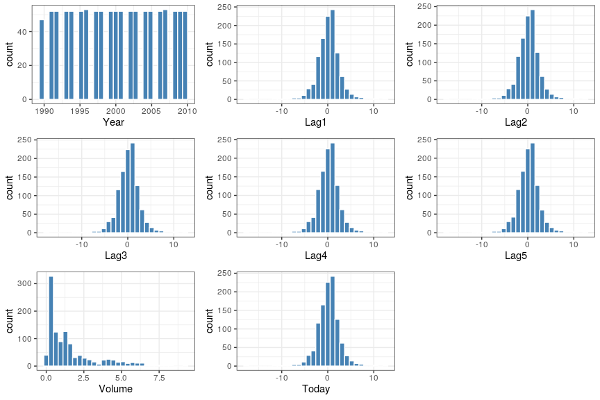

```r
bh_plot_histogram_grid(Weekly)
```

Pairs plot:

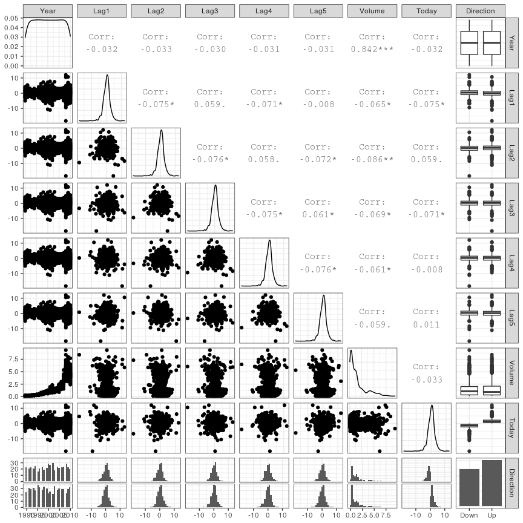

```r
ggpairs(Weekly, progress = FALSE)
```

Boxplots of `Direction` versus the other variables:

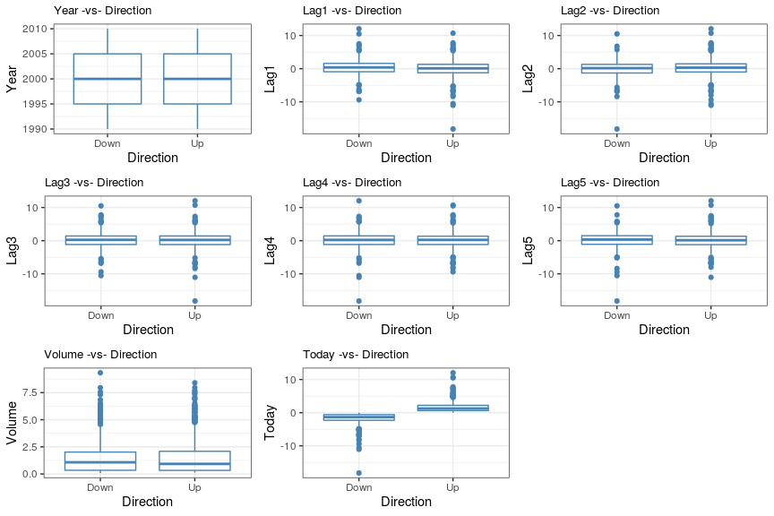

```r
bh_plot_boxplot_grid(Weekly, factor_var = "Direction")
```

### (b)

Fit a logistic regression model with `Direction` as the response and the five lag variables plus `Volume` as predictors:

```r
log1 <- glm(Direction ~ Lag1 + Lag2 + Lag3 + Lag4 + Lag5 + Volume, data = Weekly, family = binomial)
summary(log1)
```

```
Call:
glm(formula = Direction ~ Lag1 + Lag2 + Lag3 + Lag4 + Lag5 +
    Volume, family = binomial, data = Weekly)

Deviance Residuals:
    Min       1Q   Median       3Q      Max
-1.6949  -1.2565   0.9913   1.0849   1.4579

Coefficients:
            Estimate Std. Error z value Pr(>|z|)
(Intercept)  0.26686    0.08593   3.106   0.0019 **
Lag1        -0.04127    0.02641  -1.563   0.1181
Lag2         0.05844    0.02686   2.175   0.0296 *
Lag3        -0.01606    0.02666  -0.602   0.5469
Lag4        -0.02779    0.02646  -1.050   0.2937
Lag5        -0.01447    0.02638  -0.549   0.5833
Volume      -0.02274    0.03690  -0.616   0.5377
---
Signif. codes:  0 ‘***’ 0.001 ‘**’ 0.01 ‘*’ 0.05 ‘.’ 0.1 ‘ ’ 1

(Dispersion parameter for binomial family taken to be 1)

    Null deviance: 1496.2  on 1088  degrees of freedom
Residual deviance: 1486.4  on 1082  degrees of freedom
AIC: 1500.4

Number of Fisher Scoring iterations: 4
```

The variable `Lag2` is the only one which appears to have an association with `Direction` ($p=0.0296$).

### (c)

```r
contrasts(Weekly$Direction)
```

```
     Up
Down  0
Up    1
```

```r
log1_probs <- predict(log1, type = "response")
log1_preds <- rep("Down", nrow(Weekly))
log1_preds[log1_probs > 0.5] <- "Up"
test_rates(log1_preds, Weekly$Direction)
```

```
               test_label
predicted_label Down  Up
           Down   54  48
           Up    430 557
[1] "Test accuracy: 56.11"
[1] "Test error rate: 43.89"
```

This tells us that the model was correct ~56.1% of the time.

The `confusionMatrix` function in the `caret` package provides a confusion matrix as well as a range of useful metrics, including accuracy, sensitivity and specificity:

```r
caret::confusionMatrix(factor(log1_preds), Weekly$Direction, positive = "Up")
```

```
Confusion Matrix and Statistics

          Reference
Prediction Down  Up
      Down   54  48
      Up    430 557

               Accuracy : 0.5611
                 95% CI : (0.531, 0.5908)
    No Information Rate : 0.5556
    P-Value [Acc > NIR] : 0.369

                  Kappa : 0.035

 Mcnemar's Test P-Value : <2e-16

            Sensitivity : 0.9207
            Specificity : 0.1116
         Pos Pred Value : 0.5643
         Neg Pred Value : 0.5294
             Prevalence : 0.5556
         Detection Rate : 0.5115
   Detection Prevalence : 0.9063
      Balanced Accuracy : 0.5161

       'Positive' Class : Up
```

### (d)

Fit a logistic regression model using a training data period from 1990 to 2008, with `Lag2` as the only predictor:

```r
train <- (Weekly$Year <= 2008)
log2 <- glm(Direction ~ Lag2, data = Weekly, family = binomial, subset = train)
summary(log2)
```

```
Call:
glm(formula = Direction ~ Lag2, family = binomial, data = Weekly,
    subset = train)

Deviance Residuals:
   Min      1Q  Median      3Q     Max
-1.536  -1.264   1.021   1.091   1.368

Coefficients:
            Estimate Std. Error z value Pr(>|z|)
(Intercept)  0.20326    0.06428   3.162  0.00157 **
Lag2         0.05810    0.02870   2.024  0.04298 *
---
Signif. codes:  0 ‘***’ 0.001 ‘**’ 0.01 ‘*’ 0.05 ‘.’ 0.1 ‘ ’ 1

(Dispersion parameter for binomial family taken to be 1)

    Null deviance: 1354.7  on 984  degrees of freedom
Residual deviance: 1350.5  on 983  degrees of freedom
AIC: 1354.5

Number of Fisher Scoring iterations: 4
```

Confusion matrix and test accuracy:

```r
log2_probs <- predict(log2, newdata = Weekly[!train, ], type = "response")
log2_preds <- rep("Down", nrow(Weekly[!train, ]))
log2_preds[log2_probs > 0.5] <- "Up"
test_rates(log2_preds, Weekly$Direction[!train])
```

```
               test_label
predicted_label Down Up
           Down    9  5
           Up     34 56
[1] "Test accuracy: 62.5"
[1] "Test error rate: 37.5"
```

This tells us that the model was correct ~62.5% of the time.

The `confusionMatrix` function in the `caret` package provides a confusion matrix as well as a range of useful metrics, including accuracy, sensitivity and specificity:

```r
caret::confusionMatrix(factor(log2_preds), Weekly$Direction[!train], positive = "Up")
```

```
Confusion Matrix and Statistics

          Reference
Prediction Down Up
      Down    9  5
      Up     34 56

               Accuracy : 0.625
                 95% CI : (0.5247, 0.718)
    No Information Rate : 0.5865
    P-Value [Acc > NIR] : 0.2439

                  Kappa : 0.1414

 Mcnemar's Test P-Value : 7.34e-06

            Sensitivity : 0.9180
            Specificity : 0.2093
         Pos Pred Value : 0.6222
         Neg Pred Value : 0.6429
             Prevalence : 0.5865
         Detection Rate : 0.5385
   Detection Prevalence : 0.8654
      Balanced Accuracy : 0.5637

       'Positive' Class : Up
```

### (e)

Fit an LDA model using a training data period from 1990 to 2008, with `Lag2` as the only predictor:

```r
train <- (Weekly$Year <= 2008)
lda1 <- lda(Direction ~ Lag2, data = Weekly, family = binomial, subset = train)
lda1
```

```
Call:
lda(Direction ~ Lag2, data = Weekly, family = binomial, subset = train)

Prior probabilities of groups:
     Down        Up
0.4477157 0.5522843

Group means:
            Lag2
Down -0.03568254
Up    0.26036581

Coefficients of linear discriminants:
           LD1
Lag2 0.4414162
```

The Group means can also be calculated directly from the data:

```r
mean((Weekly$Lag2[train])[Weekly$Direction[train]=="Down"])
```

```
[1] -0.03568254
```

```r
mean((Weekly$Lag2[train])[Weekly$Direction[train]=="Up"])
```

```
[1] 0.2603658
```

Use the model to make predictions on the test data:

```r
lda1_pred <- predict(lda1, newdata = Weekly[!train, ])
names(lda1_pred)
```

```
[1] "class"     "posterior" "x"
```

Construct a confusion matrix:

```r
lda1_class <- lda1_pred$class
test_rates(lda1_class, Weekly$Direction[!train])
```

```
               test_label
predicted_label Down Up
           Down    9  5
           Up     34 56
[1] "Test accuracy: 62.5"
[1] "Test error rate: 37.5"
```

We see that the numbers are identical to the logistic regression model in part (d).

Recreate the number of predictions for each `Direction` using the model’s `posterior`’s:

```r
sum(lda1_pred$posterior[, 1] > 0.5)
```

```
[1] 14
```

```r
sum(lda1_pred$posterior[, 1] < 0.5)
```

```
[1] 90
```

The model predicts `Up` as the direction ~86.5% of the time.

Notice that the posterior probability output by the model corresponds to the probability that the market will *decrease*.

```r
round(lda1_pred$posterior[1:10, 1], 2)
```

```
 986  987  988  989  990  991  992  993  994  995
0.47 0.36 0.51 0.51 0.48 0.46 0.38 0.52 0.55 0.51
```

```r
lda1_class[1:10]
```

```
 [1] Up   Up   Down Down Up   Up   Up   Down Down Down
Levels: Down Up
```

The `confusionMatrix` function in the `caret` package provides a confusion matrix as well as a range of useful metrics, including accuracy, sensitivity and specificity:

```r
caret::confusionMatrix(factor(lda1_class), Weekly$Direction[!train], positive = "Up")
```

```
Confusion Matrix and Statistics

          Reference
Prediction Down Up
      Down    9  5
      Up     34 56

               Accuracy : 0.625
                 95% CI : (0.5247, 0.718)
    No Information Rate : 0.5865
    P-Value [Acc > NIR] : 0.2439

                  Kappa : 0.1414

 Mcnemar's Test P-Value : 7.34e-06

            Sensitivity : 0.9180
            Specificity : 0.2093
         Pos Pred Value : 0.6222
         Neg Pred Value : 0.6429
             Prevalence : 0.5865
         Detection Rate : 0.5385
   Detection Prevalence : 0.8654
      Balanced Accuracy : 0.5637

       'Positive' Class : Up
```

### (f)

Fit a QDA model using a training data period from 1990 to 2008, with `Lag2` as the only predictor:

```r
train <- (Weekly$Year <= 2008)
qda1 <- qda(Direction ~ Lag2, data = Weekly, family = binomial, subset = train)
qda1
```

```
Call:
qda(Direction ~ Lag2, data = Weekly, family = binomial, subset = train)

Prior probabilities of groups:
     Down        Up
0.4477157 0.5522843

Group means:
            Lag2
Down -0.03568254
Up    0.26036581
```

Use the model to make predictions on the test data:

```r
qda1_pred <- predict(qda1, newdata = Weekly[!train, ])
names(qda1_pred)
```

```
[1] "class"     "posterior"
```

Construct a confusion matrix:

```r
qda1_class <- qda1_pred$class
test_rates(qda1_class, Weekly$Direction[!train])
```

```
               test_label
predicted_label Down Up
           Down    0  0
           Up     43 61
[1] "Test accuracy: 58.65"
[1] "Test error rate: 41.35"
```

Number of correct predictions as fraction of total:

```r
(0 + 61) / length(Weekly$Direction[!train])
```

```
[1] 0.5865385
```

This can also be calculated using `mean()`:

```r
mean(qda1_class == Weekly$Direction[!train])
```

```
[1] 0.5865385
```

This tells us that the model was correct ~58.7% of the time. Additionally, we can calculate a **test error rate** of 41.3% ($(1 - 0.587)\times100$).

When the model predicts `Up`, how often is it correct?

```r
61 / (43 + 61)
```

```
[1] 0.5865385
```

The model has poorer performance than the logistic regression and LDA models when predicting `Up`, and actually never predicts `Down` as the class.

This means that when the market is `Up` it is always correct (100% accurate), and when the market is `Down` it is always wrong (0% accuracy):

```r
100 * 61 / (0 + 61) # `Up`
```

```
[1] 100
```

```r
100 * 0 / (0 + 43) # `Down`
```

```
[1] 0
```

The `confusionMatrix` function in the `caret` package provides a confusion matrix as well as a range of useful metrics, including accuracy, sensitivity and specificity:

```r
caret::confusionMatrix(factor(qda1_class), Weekly$Direction[!train], positive = "Up")
```

```
Levels are not in the same order for reference and data. Refactoring data to match.
```

```
Confusion Matrix and Statistics

          Reference
Prediction Down Up
      Down    0  0
      Up     43 61

               Accuracy : 0.5865
                 95% CI : (0.4858, 0.6823)
    No Information Rate : 0.5865
    P-Value [Acc > NIR] : 0.5419

                  Kappa : 0

 Mcnemar's Test P-Value : 1.504e-10

            Sensitivity : 1.0000
            Specificity : 0.0000
         Pos Pred Value : 0.5865
         Neg Pred Value :    NaN
             Prevalence : 0.5865
         Detection Rate : 0.5865
   Detection Prevalence : 1.0000
      Balanced Accuracy : 0.5000

       'Positive' Class : Up
```

### (g)

To use `knn()`, convert the training data using `as.matrix()`:

```r
library(class)
train.X <- as.matrix(Weekly$Lag2[train])
test.X <- as.matrix(Weekly$Lag2[!train])
train.Y <- Weekly$Direction[train]
```

Fit a KNN model using a training data period from 1990 to 2008, with `Lag2` as the only predictor:

```r
set.seed(1)
knn.pred <- knn(train.X, test.X, train.Y, k=1)
test_rates(knn.pred, Weekly$Direction[!train])
```

```
               test_label
predicted_label Down Up
           Down   21 30
           Up     22 31
[1] "Test accuracy: 50"
[1] "Test error rate: 50"
```

Number of correct predictions as fraction of total:

```r
(21 + 31) / length(Weekly$Direction[!train])
```

```
[1] 0.5
```

This can also be calculated using `mean()`:

```r
mean(knn.pred == Weekly$Direction[!train])
```

```
[1] 0.5
```

This tells us that KNN was correct 50% of the time. Additionally, we can calculate a **test error rate** of 50% ($(1 - 0.5)\times100$).

In the below table we see that KNN predicts `Up` and `Down` almost equally often:

```r
summary(knn.pred)
```

```
Down   Up
  51   53
```

The `confusionMatrix` function in the `caret` package provides a confusion matrix as well as a range of useful metrics, including accuracy, sensitivity and specificity:

```r
caret::confusionMatrix(knn.pred, Weekly$Direction[!train], positive = "Up")
```

```
Confusion Matrix and Statistics

          Reference
Prediction Down Up
      Down   21 30
      Up     22 31

               Accuracy : 0.5
                 95% CI : (0.4003, 0.5997)
    No Information Rate : 0.5865
    P-Value [Acc > NIR] : 0.9700

                  Kappa : -0.0033

 Mcnemar's Test P-Value : 0.3317

            Sensitivity : 0.5082
            Specificity : 0.4884
         Pos Pred Value : 0.5849
         Neg Pred Value : 0.4118
             Prevalence : 0.5865
         Detection Rate : 0.2981
   Detection Prevalence : 0.5096
      Balanced Accuracy : 0.4983

       'Positive' Class : Up
```

### (h)

The logistic regression and LDA models both had a test error of 37.5%. QDA had a test error of 41.3% and KNN had a test error of 50%. Using test error as a metric we can say that logistic regression and LDA were joint best.

### (i)

Data:

```r
train <- (Weekly$Year <= 2008) # Use years 1990 to 2008 for training
Weekly.test <- Weekly[!train, ]
Direction.test <- Weekly$Direction[!train]
```

#### LDA Models

```r
lda.fit <- lda(Direction ~ Lag1 + Lag2, data=Weekly, subset=train)
lda.pred <- predict(lda.fit, Weekly.test)
lda.class <- lda.pred$class
test_rates(lda.class, Direction.test)
```

```
               test_label
predicted_label Down Up
           Down    7  8
           Up     36 53
[1] "Test accuracy: 57.69"
[1] "Test error rate: 42.31"
```

```r
lda.fit <- lda(Direction ~ Lag1:Lag2, data=Weekly, subset=train)
lda.pred <- predict(lda.fit, Weekly.test)
lda.class <- lda.pred$class
test_rates(lda.class, Direction.test)
```

```
               test_label
predicted_label Down Up
           Down    0  1
           Up     43 60
[1] "Test accuracy: 57.69"
[1] "Test error rate: 42.31"
```

```r
lda.fit <- lda(Direction ~ Lag2 + Volume, data=Weekly, subset=train)
lda.pred <- predict(lda.fit, Weekly.test)
lda.class <- lda.pred$class
test_rates(lda.class, Direction.test)
```

```
               test_label
predicted_label Down Up
           Down   20 25
           Up     23 36
[1] "Test accuracy: 53.85"
[1] "Test error rate: 46.15"
```

```r
lda.fit <- lda(Direction ~ Lag2*Volume, data=Weekly, subset=train)
lda.pred <- predict(lda.fit, Weekly.test)
lda.class <- lda.pred$class
test_rates(lda.class, Direction.test)
```

```
               test_label
predicted_label Down Up
           Down   20 25
           Up     23 36
[1] "Test accuracy: 53.85"
[1] "Test error rate: 46.15"
```

#### QDA Models

```r
qda.fit <- qda(Direction ~ Lag1 + Lag2, Weekly, subset=train)
qda.pred <- predict(qda.fit, Weekly.test)
qda.class <- qda.pred$class
test_rates(qda.class, Direction.test)
```

```
               test_label
predicted_label Down Up
           Down    7 10
           Up     36 51
[1] "Test accuracy: 55.77"
[1] "Test error rate: 44.23"
```

```r
qda.fit <- qda(Direction ~ Lag1:Lag2, Weekly, subset=train)
qda.pred <- predict(qda.fit, Weekly.test)
qda.class <- qda.pred$class
test_rates(qda.class, Direction.test)
```

```
               test_label
predicted_label Down Up
           Down   16 32
           Up     27 29
[1] "Test accuracy: 43.27"
[1] "Test error rate: 56.73"
```

```r
qda.fit <- qda(Direction ~ Lag2 + Volume, Weekly, subset=train)
qda.pred <- predict(qda.fit, Weekly.test)
qda.class <- qda.pred$class
test_rates(qda.class, Direction.test)
```

```
               test_label
predicted_label Down Up
           Down   32 44
           Up     11 17
[1] "Test accuracy: 47.12"
[1] "Test error rate: 52.88"
```

```r
qda.fit <- qda(Direction ~ Lag2*Volume, Weekly, subset=train)
qda.pred <- predict(qda.fit, Weekly.test)
qda.class <- qda.pred$class
test_rates(qda.class, Direction.test)
```

```
               test_label
predicted_label Down Up
           Down   37 49
           Up      6 12
[1] "Test accuracy: 47.12"
[1] "Test error rate: 52.88"
```

#### KNN

```r
set.seed(1)
k <- 1:100
knn_list <- map(k,
                function(k) {
                    knn(train.X, test.X, train.Y, k = k)
                }
            )

knn_errors <- map_dbl(knn_list,
                      function(preds) {
                        100*round(1 - mean(preds == Direction.test), 4)
                      }
              )

paste0("Value of k with lowest test error: ", which.min(knn_errors), " (", min(knn_errors), "%)")
```

```
[1] "Value of k with lowest test error: 47 (38.46%)"
```

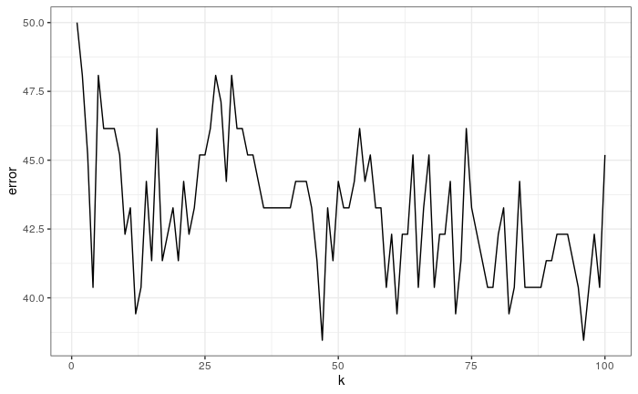

```r
knn_errors_df <- data.frame(k, error = knn_errors)
ggplot(knn_errors_df) +
  geom_line(aes(k, error))
```

For KNN, a value of $k=47$ has the lowest test error at 38.46%. However a value of $k=12$ gives a comparably low test error of 39.42%:

```r
knn_errors_df %>%
  arrange(error)
```

| k | error |
| --- | --- |
| 47 | 38.46 |
| 96 | 38.46 |
| 12 | 39.42 |
| 61 | 39.42 |
| 72 | 39.42 |
| 82 | 39.42 |
| 4 | 40.38 |
| 13 | 40.38 |
| 59 | 40.38 |
| 65 | 40.38 |

[output cut: 90 more lines]

## Exercise 11

### (a)

View data:

```r
Auto
```

|  | mpg | cylinders | displacement | horsepower | weight | acceleration | year | origin | name |
| --- | --- | --- | --- | --- | --- | --- | --- | --- | --- |
| 1 | 18.0 | 8 | 307.0 | 130 | 3504 | 12.0 | 70 | 1 | chevrolet chevelle malibu |
| 2 | 15.0 | 8 | 350.0 | 165 | 3693 | 11.5 | 70 | 1 | buick skylark 320 |
| 3 | 18.0 | 8 | 318.0 | 150 | 3436 | 11.0 | 70 | 1 | plymouth satellite |
| 4 | 16.0 | 8 | 304.0 | 150 | 3433 | 12.0 | 70 | 1 | amc rebel sst |
| 5 | 17.0 | 8 | 302.0 | 140 | 3449 | 10.5 | 70 | 1 | ford torino |
| 6 | 15.0 | 8 | 429.0 | 198 | 4341 | 10.0 | 70 | 1 | ford galaxie 500 |
| 7 | 14.0 | 8 | 454.0 | 220 | 4354 | 9.0 | 70 | 1 | chevrolet impala |
| 8 | 14.0 | 8 | 440.0 | 215 | 4312 | 8.5 | 70 | 1 | plymouth fury iii |
| 9 | 14.0 | 8 | 455.0 | 225 | 4425 | 10.0 | 70 | 1 | pontiac catalina |
| 10 | 15.0 | 8 | 390.0 | 190 | 3850 | 8.5 | 70 | 1 | amc ambassador dpl |

[output cut: 382 more lines]

Summary:

```r
bh_print_data_summary(Auto)
```

```
                      [,1]
num_rows              "   392"
num_cols              "     9"
num_categorical_cols  "     1"
num_numeric_cols      "     8"
all_missing_cols      "     0"
complete_cols         "     9"
total_missing         "     0"
total_percent_missing "     0"
total_data_points     " 3,528"
size_bytes            "78,600"
```

Median value of `mpg`:

```r
median(Auto$mpg)
```

```
[1] 22.75
```

Clean data and create the `mpg01` variable:

```r
Auto <- ISLR::Auto
Auto <- Auto %>%
  mutate(mpg01 = ifelse(mpg > median(mpg), 1, 0),
         mpg01 = factor(mpg01),
         cylinders = factor(cylinders),
         origin = factor(origin)) %>%
  dplyr::select(mpg, mpg01, everything())
Auto
```

|  | mpg | mpg01 | cylinders | displacement | horsepower | weight | acceleration | year | origin | name |
| --- | --- | --- | --- | --- | --- | --- | --- | --- | --- | --- |
| 1 | 18.0 | 0 | 8 | 307.0 | 130 | 3504 | 12.0 | 70 | 1 | chevrolet chevelle malibu |
| 2 | 15.0 | 0 | 8 | 350.0 | 165 | 3693 | 11.5 | 70 | 1 | buick skylark 320 |
| 3 | 18.0 | 0 | 8 | 318.0 | 150 | 3436 | 11.0 | 70 | 1 | plymouth satellite |
| 4 | 16.0 | 0 | 8 | 304.0 | 150 | 3433 | 12.0 | 70 | 1 | amc rebel sst |
| 5 | 17.0 | 0 | 8 | 302.0 | 140 | 3449 | 10.5 | 70 | 1 | ford torino |
| 6 | 15.0 | 0 | 8 | 429.0 | 198 | 4341 | 10.0 | 70 | 1 | ford galaxie 500 |
| 7 | 14.0 | 0 | 8 | 454.0 | 220 | 4354 | 9.0 | 70 | 1 | chevrolet impala |
| 8 | 14.0 | 0 | 8 | 440.0 | 215 | 4312 | 8.5 | 70 | 1 | plymouth fury iii |
| 9 | 14.0 | 0 | 8 | 455.0 | 225 | 4425 | 10.0 | 70 | 1 | pontiac catalina |
| 10 | 15.0 | 0 | 8 | 390.0 | 190 | 3850 | 8.5 | 70 | 1 | amc ambassador dpl |

[output cut: 382 more lines]

### (b)

Histograms for all numeric variables:

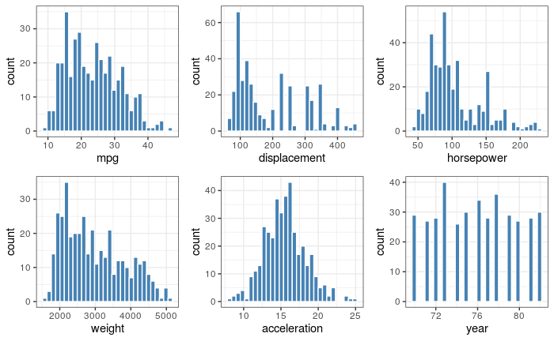

```r
bh_plot_histogram_grid(Auto)
```

Boxplots of `mpg01` versus the other numeric variables:

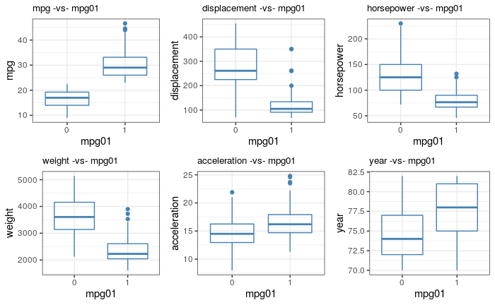

```r
bh_plot_boxplot_grid(Auto, "mpg01")
```

All of the boxplots (ignore the `mpg` one) show that there could be a relationship with `mpg` and the variable in question.

Make boxplots of the other categorical variables, `origin` and `cylinders`, and `mpg` (rather than `mpg01`):

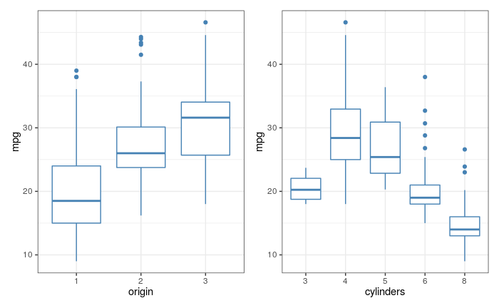

```r
p1 <- ggplot(Auto) +
  geom_boxplot(aes(origin, mpg), color = "steelblue")

p2 <- ggplot(Auto) +
  geom_boxplot(aes(cylinders, mpg), color = "steelblue")

p1 + p2
```

Both of these variables also look like they have a relationship with `mpg`.

### (c)

Split the data into a training set and a test set:

```r
set.seed(3)
test <- sample(1:nrow(Auto), nrow(Auto)/5) # save 1/5 of the data as a test set
```

### (d)

Fit an LDA model:

```r
lda1 <- lda(mpg01 ~ cylinders + displacement + horsepower + weight + acceleration + year + origin, data = Auto[-test, ])
lda1
```

```
Call:
lda(mpg01 ~ cylinders + displacement + horsepower + weight +
    acceleration + year + origin, data = Auto[-test, ])

Prior probabilities of groups:
  0   1
0.5 0.5

Group means:
  cylinders4  cylinders5 cylinders6 cylinders8 displacement horsepower   weight acceleration     year    origin2    origin3
0  0.1082803 0.006369427 0.36942675 0.50318471     273.4140  129.97452 3608.561     14.63822 74.57325 0.06369427 0.04458599
1  0.9171975 0.006369427 0.05095541 0.01910828     116.1051   79.07643 2332.662     16.40955 77.71338 0.26751592 0.34394904

Coefficients of linear discriminants:
                       LD1
cylinders4    2.557646e+00
cylinders5    9.811776e-01
cylinders6    1.600268e-01
cylinders8    8.391250e-01
displacement  6.566377e-05
horsepower    3.105650e-03
weight       -1.042991e-03
acceleration -3.474137e-03
year          1.455029e-01
origin2       2.591215e-01
origin3       2.742946e-01
```

Calculate test accuracy:

```r
lda1_preds <- predict(lda1, newdata = Auto[test, ])
lda1_class <- lda1_preds$class
test_rates(lda1_class, Auto$mpg01[test])
```

```
               test_label
predicted_label  0  1
              0 36  4
              1  3 35
[1] "Test accuracy: 91.03"
[1] "Test error rate: 8.97"
```

### (e)

Fit a QDA model:

```r
qda1 <- qda(mpg01 ~ cylinders + displacement + horsepower + weight + acceleration + year + origin, data = Auto[-test, ])
qda1
```

```
Call:
qda(mpg01 ~ cylinders + displacement + horsepower + weight +
    acceleration + year + origin, data = Auto[-test, ])

Prior probabilities of groups:
  0   1
0.5 0.5

Group means:
  cylinders4  cylinders5 cylinders6 cylinders8 displacement horsepower   weight acceleration     year    origin2    origin3
0  0.1082803 0.006369427 0.36942675 0.50318471     273.4140  129.97452 3608.561     14.63822 74.57325 0.06369427 0.04458599
1  0.9171975 0.006369427 0.05095541 0.01910828     116.1051   79.07643 2332.662     16.40955 77.71338 0.26751592 0.34394904
```

Calculate test accuracy:

```r
qda1_preds <- predict(qda1, newdata = Auto[test, ])
qda1_class <- qda1_preds$class
test_rates(qda1_class, Auto$mpg01[test])
```

```
               test_label
predicted_label  0  1
              0 34  2
              1  5 37
[1] "Test accuracy: 91.03"
[1] "Test error rate: 8.97"
```

### (f)

Fit a logistic regression model:

```r
log1 <- glm(mpg01 ~ cylinders + displacement + horsepower + weight + acceleration + year + origin,
            data = Auto[-test, ],
            family = binomial)
summary(log1)
```

```
Call:
glm(formula = mpg01 ~ cylinders + displacement + horsepower +
    weight + acceleration + year + origin, family = binomial,
    data = Auto[-test, ])

Deviance Residuals:
     Min        1Q    Median        3Q       Max
-3.14309  -0.04127   0.00083   0.07186   2.53189

Coefficients:
               Estimate Std. Error z value Pr(>|z|)
(Intercept)  -44.545401  11.280154  -3.949 7.85e-05 ***
cylinders4     5.386586   2.148780   2.507 0.012183 *
cylinders5     1.313978   2.634165   0.499 0.617905
cylinders6     2.774983   2.395693   1.158 0.246733
cylinders8     7.845518   3.600553   2.179 0.029333 *
displacement   0.003683   0.016287   0.226 0.821122
horsepower    -0.024532   0.033780  -0.726 0.467702
weight        -0.007080   0.001845  -3.837 0.000124 ***
acceleration  -0.018432   0.186017  -0.099 0.921069
year           0.800566   0.157173   5.094 3.51e-07 ***
origin2        2.397823   1.047021   2.290 0.022013 *
origin3        1.561971   0.942086   1.658 0.097319 .
---
Signif. codes:  0 ‘***’ 0.001 ‘**’ 0.01 ‘*’ 0.05 ‘.’ 0.1 ‘ ’ 1

(Dispersion parameter for binomial family taken to be 1)

    Null deviance: 435.296  on 313  degrees of freedom
Residual deviance:  88.952  on 302  degrees of freedom
AIC: 112.95

Number of Fisher Scoring iterations: 8
```

Calculate test accuracy:

```r
log1_probs <- predict(log1, newdata = Auto[test, ], type = "response")
log1_preds <- rep(0, length(Auto$mpg01[test]))
log1_preds[log1_probs > 0.5] <- 1
test_rates(log1_preds, Auto$mpg01[test])
```

```
               test_label
predicted_label  0  1
              0 36  5
              1  3 34
[1] "Test accuracy: 89.74"
[1] "Test error rate: 10.26"
```

### (g)

Fit a KNN model:

```r
vars <- c("cylinders", "displacement", "horsepower", "weight", "acceleration", "year", "origin")
train.X <- Auto[-test, vars]
test.X <- Auto[test, vars]
train.Y <- Auto$mpg01[-test]

set.seed(1)
k <- 1:100
knn_list <- map(k,
                function(k) {
                    knn(train.X, test.X, train.Y, k = k)
                }
            )

knn_errors <- map_dbl(knn_list,
                      function(preds) {
                        100*round(1 - mean(preds == Auto$mpg01[test]), 4)
                      }
              )

paste0("Value of k with lowest test error: ", which.min(knn_errors), " (", min(knn_errors), "%)")
```

```
[1] "Value of k with lowest test error: 3 (7.69%)"
```

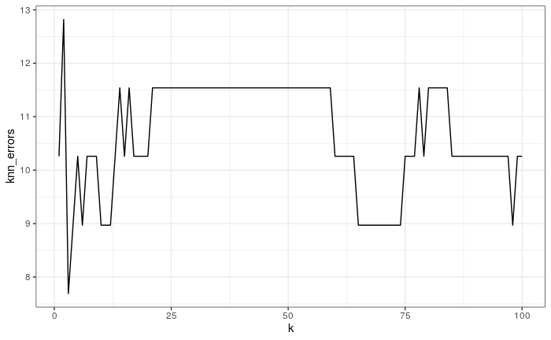

```r
data.frame(k, knn_errors) %>%
  ggplot() +
  geom_line(aes(k, knn_errors))
```

## Exercise 12

### (a)

```r
Power <- function() {
  print(2^3)
}

Power()
```

```
[1] 8
```

### (b)

```r
Power2 <- function(x, a) {
  print(x^a)
}

Power2(3, 8)
```

```
[1] 6561
```

```r
Power2(2, 1:10)
```

```
 [1]    2    4    8   16   32   64  128  256  512 1024
```

### (c)

```r
Power2(c(10, 8, 131), c(3, 17, 3))
```

```
[1] 1.000000e+03 2.251800e+15 2.248091e+06
```

### (d)

```r
Power3 <- function(x, a) {
  return(x^a)
}

x <- Power3(2, 3)
x
```

```
[1] 8
```

### (e)

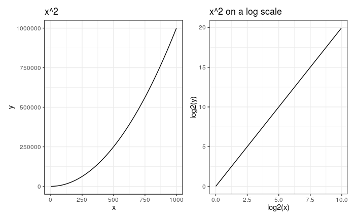

```r
x <- 1:1000
y <- Power3(x, 2)

p1 <- data.frame(x, y) %>%
  ggplot() +
  geom_line(aes(x, y)) +
  ggtitle("x^2")

p2 <- data.frame(x, y) %>%
  ggplot() +
  geom_line(aes(log2(x), log2(y))) +
  ggtitle("x^2 on a log scale")

p1 + p2
```

### (f)

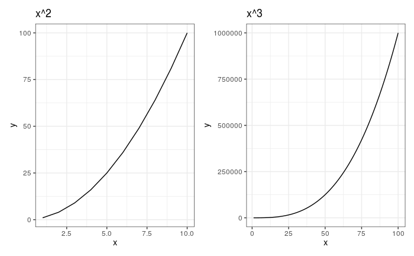

```r
PlotPower <- function(x, a) {
  y <- Power3(x, a)
  g <- tibble(x, y) %>%
    ggplot() +
    geom_line(aes(x, y))
  return(g)
}

p1 <- PlotPower(1:10, 2) + ggtitle("x^2")
p2 <- PlotPower(1:100, 3) + ggtitle("x^3")
p1 + p2
```

## Exercise 13

### (a)

View data:

```r
Boston
```

|  | crim | zn | indus | chas | nox | rm | age | dis | rad | tax | ptratio | black | lstat | medv |
| --- | --- | --- | --- | --- | --- | --- | --- | --- | --- | --- | --- | --- | --- | --- |
| 1 | 0.00632 | 18.0 | 2.31 | 0 | 0.5380 | 6.575 | 65.2 | 4.0900 | 1 | 296 | 15.3 | 396.90 | 4.98 | 24.0 |
| 2 | 0.02731 | 0.0 | 7.07 | 0 | 0.4690 | 6.421 | 78.9 | 4.9671 | 2 | 242 | 17.8 | 396.90 | 9.14 | 21.6 |
| 3 | 0.02729 | 0.0 | 7.07 | 0 | 0.4690 | 7.185 | 61.1 | 4.9671 | 2 | 242 | 17.8 | 392.83 | 4.03 | 34.7 |
| 4 | 0.03237 | 0.0 | 2.18 | 0 | 0.4580 | 6.998 | 45.8 | 6.0622 | 3 | 222 | 18.7 | 394.63 | 2.94 | 33.4 |
| 5 | 0.06905 | 0.0 | 2.18 | 0 | 0.4580 | 7.147 | 54.2 | 6.0622 | 3 | 222 | 18.7 | 396.90 | 5.33 | 36.2 |
| 6 | 0.02985 | 0.0 | 2.18 | 0 | 0.4580 | 6.430 | 58.7 | 6.0622 | 3 | 222 | 18.7 | 394.12 | 5.21 | 28.7 |
| 7 | 0.08829 | 12.5 | 7.87 | 0 | 0.5240 | 6.012 | 66.6 | 5.5605 | 5 | 311 | 15.2 | 395.60 | 12.43 | 22.9 |
| 8 | 0.14455 | 12.5 | 7.87 | 0 | 0.5240 | 6.172 | 96.1 | 5.9505 | 5 | 311 | 15.2 | 396.90 | 19.15 | 27.1 |
| 9 | 0.21124 | 12.5 | 7.87 | 0 | 0.5240 | 5.631 | 100.0 | 6.0821 | 5 | 311 | 15.2 | 386.63 | 29.93 | 16.5 |
| 10 | 0.17004 | 12.5 | 7.87 | 0 | 0.5240 | 6.004 | 85.9 | 6.5921 | 5 | 311 | 15.2 | 386.71 | 17.10 | 18.9 |

[output cut: 496 more lines]

Summary:

```r
bh_print_data_summary(Boston)
```

```
                      [,1]
num_rows              "   506"
num_cols              "    14"
num_categorical_cols  "     0"
num_numeric_cols      "    14"
all_missing_cols      "     0"
complete_cols         "    14"
total_missing         "     0"
total_percent_missing "     0"
total_data_points     " 7,084"
size_bytes            "54,944"
```

Median value of `crim`:

```r
median(Boston$crim)
```

```
[1] 0.25651
```

Clean data and create the `crim01` variable:

```r
Boston <- MASS::Boston
Boston <- Boston %>%
  mutate(crim01 = ifelse(crim > median(crim), 1, 0),
         crim01 = factor(crim01),
         chas = factor(chas)) %>%
  dplyr::select(crim, crim01, everything())
Boston
```

|  | crim | crim01 | zn | indus | chas | nox | rm | age | dis | rad | tax | ptratio | black | lstat | medv |
| --- | --- | --- | --- | --- | --- | --- | --- | --- | --- | --- | --- | --- | --- | --- | --- |
| 1 | 0.00632 | 0 | 18.0 | 2.31 | 0 | 0.5380 | 6.575 | 65.2 | 4.0900 | 1 | 296 | 15.3 | 396.90 | 4.98 | 24.0 |
| 2 | 0.02731 | 0 | 0.0 | 7.07 | 0 | 0.4690 | 6.421 | 78.9 | 4.9671 | 2 | 242 | 17.8 | 396.90 | 9.14 | 21.6 |
| 3 | 0.02729 | 0 | 0.0 | 7.07 | 0 | 0.4690 | 7.185 | 61.1 | 4.9671 | 2 | 242 | 17.8 | 392.83 | 4.03 | 34.7 |
| 4 | 0.03237 | 0 | 0.0 | 2.18 | 0 | 0.4580 | 6.998 | 45.8 | 6.0622 | 3 | 222 | 18.7 | 394.63 | 2.94 | 33.4 |
| 5 | 0.06905 | 0 | 0.0 | 2.18 | 0 | 0.4580 | 7.147 | 54.2 | 6.0622 | 3 | 222 | 18.7 | 396.90 | 5.33 | 36.2 |
| 6 | 0.02985 | 0 | 0.0 | 2.18 | 0 | 0.4580 | 6.430 | 58.7 | 6.0622 | 3 | 222 | 18.7 | 394.12 | 5.21 | 28.7 |
| 7 | 0.08829 | 0 | 12.5 | 7.87 | 0 | 0.5240 | 6.012 | 66.6 | 5.5605 | 5 | 311 | 15.2 | 395.60 | 12.43 | 22.9 |
| 8 | 0.14455 | 0 | 12.5 | 7.87 | 0 | 0.5240 | 6.172 | 96.1 | 5.9505 | 5 | 311 | 15.2 | 396.90 | 19.15 | 27.1 |
| 9 | 0.21124 | 0 | 12.5 | 7.87 | 0 | 0.5240 | 5.631 | 100.0 | 6.0821 | 5 | 311 | 15.2 | 386.63 | 29.93 | 16.5 |
| 10 | 0.17004 | 0 | 12.5 | 7.87 | 0 | 0.5240 | 6.004 | 85.9 | 6.5921 | 5 | 311 | 15.2 | 386.71 | 17.10 | 18.9 |

[output cut: 496 more lines]

Histograms for all numeric variables:

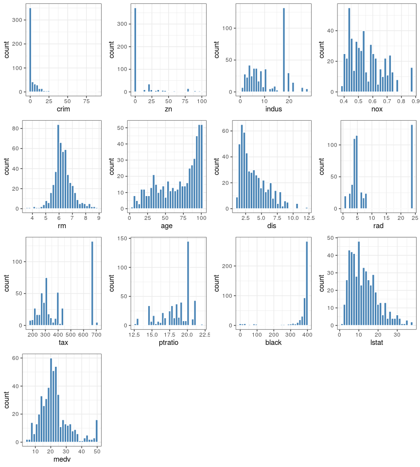

```r
bh_plot_histogram_grid(Boston)
```

Boxplots of `crim01` versus the numeric variables:

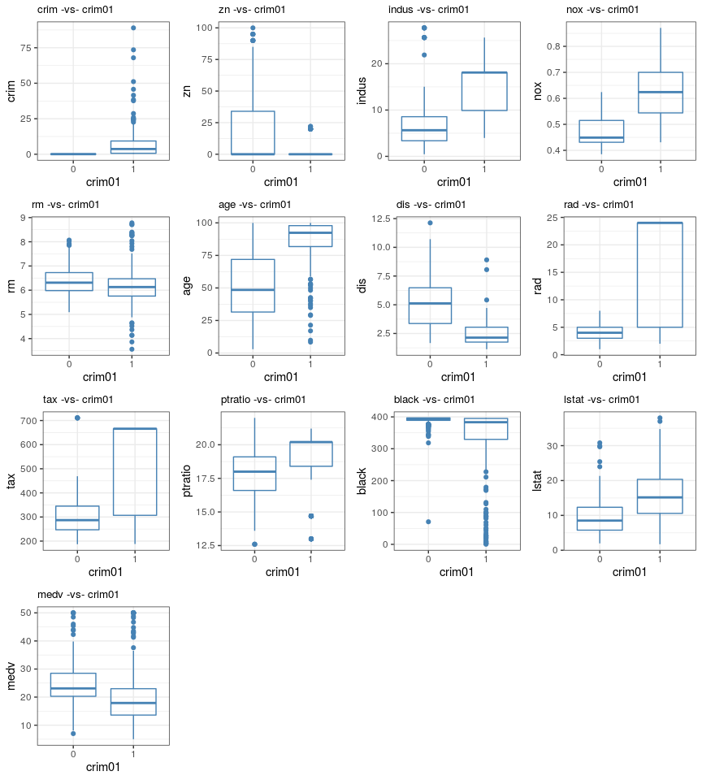

```r
bh_plot_boxplot_grid(Boston, "crim01")
```

Boxplot of the categorical variable `chas` against `crim`:

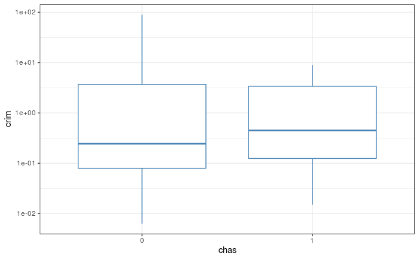

```r
ggplot(Boston) +
  geom_boxplot(aes(chas, crim), color = "steelblue") +
  scale_y_log10()
```

#### LDA

Split the data into a training and test set:

```r
set.seed(3)
test <- sample(1:nrow(Boston), round(nrow(Boston)/5)) # save 1/5 of the data as a test set
```

Fit an LDA model:

```r
lda1 <- lda(crim01 ~ . - crim, data = Boston[-test, ])
lda1
```

```
Call:
lda(crim01 ~ . - crim, data = Boston[-test, ])

Prior probabilities of groups:
        0         1
0.4987654 0.5012346

Group means:
         zn     indus      chas1       nox       rm      age      dis       rad      tax  ptratio    black    lstat     medv
0 22.269802  7.105891 0.05445545 0.4709035 6.401386 50.66485 5.140323  4.217822 304.5545 17.88119 388.3794  9.36599 25.12277
1  1.093596 15.087783 0.09359606 0.6403448 6.184069 85.43350 2.516526 15.266010 513.7931 19.00837 319.6769 15.69990 20.06798

Coefficients of linear discriminants:
                  LD1
zn      -0.0066584174
indus   -0.0182453186
chas1   -0.1294925304
nox      8.2608779300
rm       0.0835315651
age      0.0127160974
dis      0.0251417569
rad      0.0744009506
tax     -0.0004762148
ptratio  0.0773159045
black   -0.0007960605
lstat    0.0136204906
medv     0.0380707742
```

Test accuracy and other metrics:

```r
lda1_preds <- predict(lda1, newdata = Boston[test, ])
lda1_class <- lda1_preds$class
caret::confusionMatrix(lda1_class, Boston$crim01[test], positive = "1")
```

```
Confusion Matrix and Statistics

          Reference
Prediction  0  1
         0 49 14
         1  2 36

               Accuracy : 0.8416
                 95% CI : (0.7555, 0.9067)
    No Information Rate : 0.505
    P-Value [Acc > NIR] : 1.528e-12

                  Kappa : 0.6824

 Mcnemar's Test P-Value : 0.00596

            Sensitivity : 0.7200
            Specificity : 0.9608
         Pos Pred Value : 0.9474
         Neg Pred Value : 0.7778
             Prevalence : 0.4950
         Detection Rate : 0.3564
   Detection Prevalence : 0.3762
      Balanced Accuracy : 0.8404

       'Positive' Class : 1
```

#### QDA

Fit a QDA model:

```r
qda1 <- qda(crim01 ~ . - crim, data = Boston[-test, ])
qda1
```

```
Call:
qda(crim01 ~ . - crim, data = Boston[-test, ])

Prior probabilities of groups:
        0         1
0.4987654 0.5012346

Group means:
         zn     indus      chas1       nox       rm      age      dis       rad      tax  ptratio    black    lstat     medv
0 22.269802  7.105891 0.05445545 0.4709035 6.401386 50.66485 5.140323  4.217822 304.5545 17.88119 388.3794  9.36599 25.12277
1  1.093596 15.087783 0.09359606 0.6403448 6.184069 85.43350 2.516526 15.266010 513.7931 19.00837 319.6769 15.69990 20.06798
```

Test accuracy and other metrics:

```r
qda1_preds <- predict(qda1, newdata = Boston[test, ])
qda1_class <- qda1_preds$class
caret::confusionMatrix(qda1_class, Boston$crim01[test], positive = "1")
```

```
Confusion Matrix and Statistics

          Reference
Prediction  0  1
         0 49 12
         1  2 38

               Accuracy : 0.8614
                 95% CI : (0.7784, 0.9221)
    No Information Rate : 0.505
    P-Value [Acc > NIR] : 4.937e-14

                  Kappa : 0.7222

 Mcnemar's Test P-Value : 0.01616

            Sensitivity : 0.7600
            Specificity : 0.9608
         Pos Pred Value : 0.9500
         Neg Pred Value : 0.8033
             Prevalence : 0.4950
         Detection Rate : 0.3762
   Detection Prevalence : 0.3960
      Balanced Accuracy : 0.8604

       'Positive' Class : 1
```

#### Logistic Regression

Fit a logistic regression model:

```r
log1 <- glm(crim01 ~ . - crim,
            data = Boston[-test, ],
            family = binomial)
summary(log1)
```

```
Call:
glm(formula = crim01 ~ . - crim, family = binomial, data = Boston[-test,
    ])

Deviance Residuals:
    Min       1Q   Median       3Q      Max
-1.9132  -0.2119   0.0001   0.0047   3.3513

Coefficients:
              Estimate Std. Error z value Pr(>|z|)
(Intercept) -33.656009   7.163358  -4.698 2.62e-06 ***
zn           -0.085158   0.036711  -2.320 0.020358 *
indus        -0.098237   0.049969  -1.966 0.049303 *
chas1         0.629508   0.798814   0.788 0.430665
nox          43.506122   8.013018   5.429 5.65e-08 ***
rm           -0.122755   0.790314  -0.155 0.876566
age           0.022819   0.013478   1.693 0.090449 .
dis           0.549769   0.234953   2.340 0.019288 *
rad           0.576261   0.163427   3.526 0.000422 ***
tax          -0.005158   0.003058  -1.686 0.091706 .
ptratio       0.362192   0.137529   2.634 0.008449 **
black        -0.008149   0.006367  -1.280 0.200632
lstat         0.040252   0.056406   0.714 0.475460
medv          0.137239   0.070890   1.936 0.052875 .
---
Signif. codes:  0 ‘***’ 0.001 ‘**’ 0.01 ‘*’ 0.05 ‘.’ 0.1 ‘ ’ 1

(Dispersion parameter for binomial family taken to be 1)

    Null deviance: 561.45  on 404  degrees of freedom
Residual deviance: 174.29  on 391  degrees of freedom
AIC: 202.29

Number of Fisher Scoring iterations: 9
```

Test accuracy and other metrics:

```r
log1_probs <- predict(log1, newdata = Boston[test, ], type = "response")
log1_preds <- rep(0, length(Boston$crim01[test]))
log1_preds[log1_probs > 0.5] <- 1
caret::confusionMatrix(factor(log1_preds), Boston$crim01[test], positive = "1")
```

```
Confusion Matrix and Statistics

          Reference
Prediction  0  1
         0 48  4
         1  3 46

               Accuracy : 0.9307
                 95% CI : (0.8624, 0.9717)
    No Information Rate : 0.505
    P-Value [Acc > NIR] : <2e-16

                  Kappa : 0.8613

 Mcnemar's Test P-Value : 1

            Sensitivity : 0.9200
            Specificity : 0.9412
         Pos Pred Value : 0.9388
         Neg Pred Value : 0.9231
             Prevalence : 0.4950
         Detection Rate : 0.4554
   Detection Prevalence : 0.4851
      Balanced Accuracy : 0.9306

       'Positive' Class : 1
```

#### KNN

Fit a KNN model:

```r
vars <- c(1, 2)
train.X <- Boston[-test, -vars]
test.X <- Boston[test, -vars]
train.Y <- Boston$crim01[-test]

set.seed(1)
k <- 1:100
knn_list <- map(k,
                function(k) {
                    knn(train.X, test.X, train.Y, k = k)
                }
            )

knn_errors <- map_dbl(knn_list,
                      function(preds) {
                        100*round(1 - mean(preds == Boston$crim01[test]), 4)
                      }
              )

paste0("Value of k with lowest test error: ", which.min(knn_errors), " (", min(knn_errors), "%)")
```

```
[1] "Value of k with lowest test error: 4 (6.93%)"
```

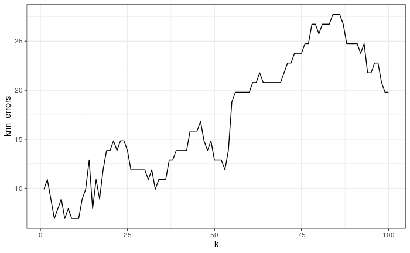

```r
data.frame(k, knn_errors) %>%
  ggplot() +
  geom_line(aes(k, knn_errors))
```

```r
cor(Boston[, numeric_cols(Boston)])
```

```
              crim         zn      indus        nox         rm        age        dis        rad        tax    ptratio      black      lstat       medv
crim     1.0000000 -0.2004692  0.4065834  0.4209717 -0.2192467  0.3527343 -0.3796701  0.6255051  0.5827643  0.2899456 -0.3850639  0.4556215 -0.3883046
zn      -0.2004692  1.0000000 -0.5338282 -0.5166037  0.3119906 -0.5695373  0.6644082 -0.3119478 -0.3145633 -0.3916785  0.1755203 -0.4129946  0.3604453
indus    0.4065834 -0.5338282  1.0000000  0.7636514 -0.3916759  0.6447785 -0.7080270  0.5951293  0.7207602  0.3832476 -0.3569765  0.6037997 -0.4837252
nox      0.4209717 -0.5166037  0.7636514  1.0000000 -0.3021882  0.7314701 -0.7692301  0.6114406  0.6680232  0.1889327 -0.3800506  0.5908789 -0.4273208
rm      -0.2192467  0.3119906 -0.3916759 -0.3021882  1.0000000 -0.2402649  0.2052462 -0.2098467 -0.2920478 -0.3555015  0.1280686 -0.6138083  0.6953599
age      0.3527343 -0.5695373  0.6447785  0.7314701 -0.2402649  1.0000000 -0.7478805  0.4560225  0.5064556  0.2615150 -0.2735340  0.6023385 -0.3769546
dis     -0.3796701  0.6644082 -0.7080270 -0.7692301  0.2052462 -0.7478805  1.0000000 -0.4945879 -0.5344316 -0.2324705  0.2915117 -0.4969958  0.2499287
rad      0.6255051 -0.3119478  0.5951293  0.6114406 -0.2098467  0.4560225 -0.4945879  1.0000000  0.9102282  0.4647412 -0.4444128  0.4886763 -0.3816262
tax      0.5827643 -0.3145633  0.7207602  0.6680232 -0.2920478  0.5064556 -0.5344316  0.9102282  1.0000000  0.4608530 -0.4418080  0.5439934 -0.4685359
ptratio  0.2899456 -0.3916785  0.3832476  0.1889327 -0.3555015  0.2615150 -0.2324705  0.4647412  0.4608530  1.0000000 -0.1773833  0.3740443 -0.5077867
black   -0.3850639  0.1755203 -0.3569765 -0.3800506  0.1280686 -0.2735340  0.2915117 -0.4444128 -0.4418080 -0.1773833  1.0000000 -0.3660869  0.3334608
lstat    0.4556215 -0.4129946  0.6037997  0.5908789 -0.6138083  0.6023385 -0.4969958  0.4886763  0.5439934  0.3740443 -0.3660869  1.0000000 -0.7376627
medv    -0.3883046  0.3604453 -0.4837252 -0.4273208  0.6953599 -0.3769546  0.2499287 -0.3816262 -0.4685359 -0.5077867  0.3334608 -0.7376627  1.0000000
```

Keep variables with correlation greater than 0.4 (in absolute value):

```r
cor_crim <- cor(Boston[, numeric_cols(Boston)])[ , "crim"]
vars <- names(cor_crim[abs(cor_crim) > 0.4])
vars <- vars[-1]
vars
```

```
[1] "indus" "nox"   "rad"   "tax"   "lstat"
```

#### LDA

```r
set.seed(3)
test <- sample(1:nrow(Boston), round(nrow(Boston)/5)) # save 1/5 of the data as a test set
```

```r
lda1 <- lda(crim01 ~ indus + nox + rad + tax + lstat, data = Boston[-test, ])
lda1
```

```
Call:
lda(crim01 ~ indus + nox + rad + tax + lstat, data = Boston[-test,
    ])

Prior probabilities of groups:
        0         1
0.4987654 0.5012346

Group means:
      indus       nox       rad      tax    lstat
0  7.105891 0.4709035  4.217822 304.5545  9.36599
1 15.087783 0.6403448 15.266010 513.7931 15.69990

Coefficients of linear discriminants:
               LD1
indus  0.003056701
nox    9.402050191
rad    0.098123955
tax   -0.001619356
lstat -0.005119816
```

```r
lda1_preds <- predict(lda1, newdata = Boston[test, ])
lda1_class <- lda1_preds$class
test_rates(lda1_class, Boston$crim01[test])
```

```
               test_label
predicted_label  0  1
              0 51 11
              1  0 39
[1] "Test accuracy: 89.11"
[1] "Test error rate: 10.89"
```

#### QDA

```r
qda1 <- qda(crim01 ~ indus + nox + rad + tax + lstat, data = Boston[-test, ])
qda1
```

```
Call:
qda(crim01 ~ indus + nox + rad + tax + lstat, data = Boston[-test,
    ])

Prior probabilities of groups:
        0         1
0.4987654 0.5012346

Group means:
      indus       nox       rad      tax    lstat
0  7.105891 0.4709035  4.217822 304.5545  9.36599
1 15.087783 0.6403448 15.266010 513.7931 15.69990
```

```r
qda1_preds <- predict(qda1, newdata = Boston[test, ])
qda1_class <- qda1_preds$class
test_rates(qda1_class, Boston$crim01[test])
```

```
               test_label
predicted_label  0  1
              0 47 15
              1  4 35
[1] "Test accuracy: 81.19"
[1] "Test error rate: 18.81"
```

#### Logistic Regression

```r
log1 <- glm(crim01 ~ indus + nox + rad + tax + lstat,
            data = Boston[-test, ],
            family = binomial)
summary(log1)
```

```
Call:
glm(formula = crim01 ~ indus + nox + rad + tax + lstat, family = binomial,
    data = Boston[-test, ])

Deviance Residuals:
    Min       1Q   Median       3Q      Max
-2.0871  -0.3002   0.0004   0.0096   2.5239

Coefficients:
              Estimate Std. Error z value Pr(>|z|)
(Intercept) -21.466600   3.100287  -6.924 4.39e-12 ***
indus        -0.097122   0.047599  -2.040   0.0413 *
nox          40.019972   6.476710   6.179 6.45e-10 ***
rad           0.518030   0.125285   4.135 3.55e-05 ***
tax          -0.005984   0.002630  -2.275   0.0229 *
lstat         0.016220   0.034552   0.469   0.6388
---
Signif. codes:  0 ‘***’ 0.001 ‘**’ 0.01 ‘*’ 0.05 ‘.’ 0.1 ‘ ’ 1

(Dispersion parameter for binomial family taken to be 1)

    Null deviance: 561.45  on 404  degrees of freedom
Residual deviance: 202.66  on 399  degrees of freedom
AIC: 214.66

Number of Fisher Scoring iterations: 8
```

```r
log1_probs <- predict(log1, newdata = Boston[test, ], type = "response")
log1_preds <- rep(0, length(Boston$crim01[test]))
log1_preds[log1_probs > 0.5] <- 1
test_rates(log1_preds, Boston$crim01[test])
```

```
               test_label
predicted_label  0  1
              0 49  8
              1  2 42
[1] "Test accuracy: 90.1"
[1] "Test error rate: 9.9"
```

#### KNN

```r
vars
```

```
[1] "indus" "nox"   "rad"   "tax"   "lstat"
```

```r
train.X <- Boston[-test, vars]
test.X <- Boston[test, vars]
train.Y <- Boston$crim01[-test]

set.seed(1)
k <- 1:100
knn_list <- map(k,
                function(k) {
                    knn(train.X, test.X, train.Y, k = k)
                }
            )

knn_errors <- map_dbl(knn_list,
                      function(preds) {
                        100*round(1 - mean(preds == Boston$crim01[test]), 4)
                      }
              )

paste0("Value of k with lowest test error: ", which.min(knn_errors), " (", min(knn_errors), "%)")
```

```
[1] "Value of k with lowest test error: 1 (5.94%)"
```

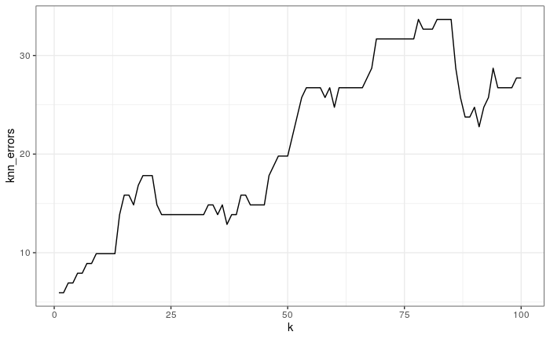

[^1]: James G, Witten D, Hastie T, Tibshirani R (2013). *An Introduction to Statistical Learning: with Applications in R*. Springer, 1st edition.